# R Markdown and Plot

Zihan Chen

2023-02-19

## Load and check data

1. Load tidyverse

```r
library(tidyverse)
```

2. load data

```r
gap <- read.delim("gapminder.csv.bz2")
```

3. The gapminder data set has 13055 rows and 25 columns.

```r
head(gap, 3)
```

```
##   iso3  name iso2   region                      sub.region intermediate.region
## 1  ABW Aruba   AW Americas Latin America and the Caribbean           Caribbean
## 2  ABW Aruba   AW Americas Latin America and the Caribbean           Caribbean
## 3  ABW Aruba   AW Americas Latin America and the Caribbean           Caribbean
##   time totalPopulation fertilityRate lifeExpectancy childMortality
## 1 1960           54211         4.820         65.662             NA
## 2 1961           55438         4.655         66.074             NA
## 3 1962           56225         4.471         66.444             NA
##   youthFemaleLiteracy youthMaleLiteracy adultLiteracy GDP_PC accessElectricity
## 1                  NA                NA            NA     NA                NA
## 2                  NA                NA            NA     NA                NA
## 3                  NA                NA            NA     NA                NA
##   agriculturalLand agricultureTractors cerealProduction fertilizerHa      co2
## 1               NA                  NA               NA           NA 11092.67
## 2               20                  NA               NA           NA 11576.72
## 3               20                  NA               NA           NA 12713.49
##   greenhouseGases   co2_PC pm2.5_35 battleDeaths
## 1              NA 204.6204       NA           NA
## 2              NA 208.8228       NA           NA
## 3              NA 226.1181       NA           NA
```

4. The data set includes the following variable: iso3, name, iso2, region, sub.region, intermediate.region, time, totalPopulation, fertilityRate, lifeExpectancy, childMortality, youthFemaleLiteracy, youthMaleLiteracy, adultLiteracy, GDP_PC, accessElectricity, agriculturalLand, agricultureTractors, cerealProduction, fertilizerHa, co2, greenhouseGases, co2_PC, pm2.5_35 and battleDeaths.
5. From the above sample of data we can see that there are a lot of missing variables, and the main reason for that might be the difficulty of accessing these data in specific countries.

## Descriptive statistics

In name column there are 250 countries.

```r
gap %>%
  select(name) %>%
  unique() %>%
  nrow()
```

```
## [1] 250
```

In iso2 column there are 249 countries.

```r
gap %>%
  select(iso2) %>%
  unique() %>%
  nrow()
```

```
## [1] 249
```

In iso3 column there are 253 countries.

```r
gap %>%
  select(iso3) %>%
  unique() %>%
  nrow()
```

```
## [1] 253
```

```r
gap %>%
  group_by(iso2) %>%
  summarize(n = n_distinct(name)) %>%
  filter(n!=1)
```

```
## # A tibble: 1 × 2
##   iso2      n
##   <chr> <int>
## 1 ""        2
```

For most iso2 codes, there is only one country correspond to that code. However, there are two countries which don’t have any iso2 code. One country is Namibia and the other country has empty name.

```r
gap %>%
  filter(iso2 == "") %>%
  select(name) %>%
  unique()
```

```
##        name
## 1
## 181 Namibia
```

```r
gap %>%
  group_by(name) %>%
  summarize(n = n_distinct(iso3)) %>%
  filter(n!=1)
```

```
## # A tibble: 1 × 2
##   name      n
##   <chr> <int>
## 1 ""        4
```

```r
gap %>%
  filter(name == "") %>%
  select(iso3) %>%
  unique()
```

```
##            iso3
## 1       CHANISL
## 61          GBM
## 121         KOS
## 181 NLD_CURACAO
```

The countries that have more than one iso3 codes are CHANISL, GBM, KOS, NLD_CURACAO. The name of the countries are empty values.

```r
gap %>%
  filter(!is.na(time)) %>%
  summarize(min = min(time), max = max(time))
```

```
##    min  max
## 1 1960 2019
```

The minimum time is 1960 and the maximum time is 2019.

## CO2 emissions

```r
gap %>%
  group_by(time) %>%
  filter(is.na(co2) | is.na(co2_PC)) %>%
  summarize(n = n()) %>%
  arrange(desc(n))
```

```
## # A tibble: 61 × 2
##     time     n
##    <int> <int>
##  1  2017   217
##  2  2018   217
##  3  2019   217
##  4  1960    60
##  5  1961    60
##  6  1962    58
##  7  1963    57
##  8  1964    51
##  9  1965    51
## 10  1966    51
## # … with 51 more rows
```

Year 2017, 2018, and 2019 have most missing data.

```r
co2_e <- gap %>%
  filter(!is.na(co2) & iso2 != "") %>%
  group_by(iso2, time) %>%
  filter(iso2 == "CN" | iso2 == "IN" | iso2 == "US" | iso2 == "JP" | iso2 == "GB") %>%
  summarise(total_co2 = co2)
co2_e
```

```
## # A tibble: 285 × 3
## # Groups:   iso2 [5]
##    iso2   time total_co2
##    <chr> <int>     <dbl>
##  1 CN     1960   780726.
##  2 CN     1961   552067.
##  3 CN     1962   440359.
##  4 CN     1963   436696.
##  5 CN     1964   436923.
##  6 CN     1965   475973.
##  7 CN     1966   522790.
##  8 CN     1967   433234.
##  9 CN     1968   468929.
## 10 CN     1969   577237.
## # … with 275 more rows
```

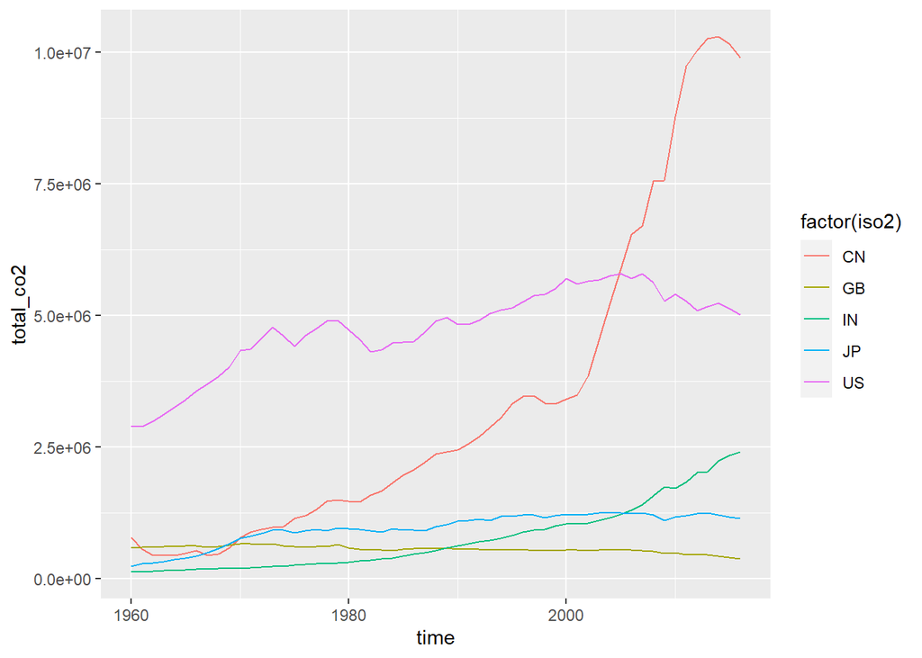

```r
ggplot(data = co2_e, mapping = aes(x = time, y = total_co2, col = factor(iso2))) +
  geom_line()
```

The CO2 emission for Britain and Japan didn’t change so much over time, but for China and India, the emission increased over time. As for the United State, the overall trend is increasing but there are a few decreases over the time period. China has the greatest growth rate and have become the country with largest total CO2 emission.The general ranking for the total emission for time closest to now is CN>US>IN>JP>GB.

```r
co2_pc_e <- gap %>%
  filter(!is.na(co2_PC) & iso2 != "") %>%
  group_by(iso2, time) %>%
  filter(iso2 == "CN" | iso2 == "IN" | iso2 == "US" | iso2 == "JP"| iso2 == "GB") %>%
  summarise(total_co2_pc = co2_PC)
co2_pc_e
```

```
## # A tibble: 285 × 3
## # Groups:   iso2 [5]
##    iso2   time total_co2_pc
##    <chr> <int>        <dbl>
##  1 CN     1960        1.17
##  2 CN     1961        0.836
##  3 CN     1962        0.661
##  4 CN     1963        0.64
##  5 CN     1964        0.626
##  6 CN     1965        0.666
##  7 CN     1966        0.711
##  8 CN     1967        0.574
##  9 CN     1968        0.605
## 10 CN     1969        0.725
## # … with 275 more rows
```

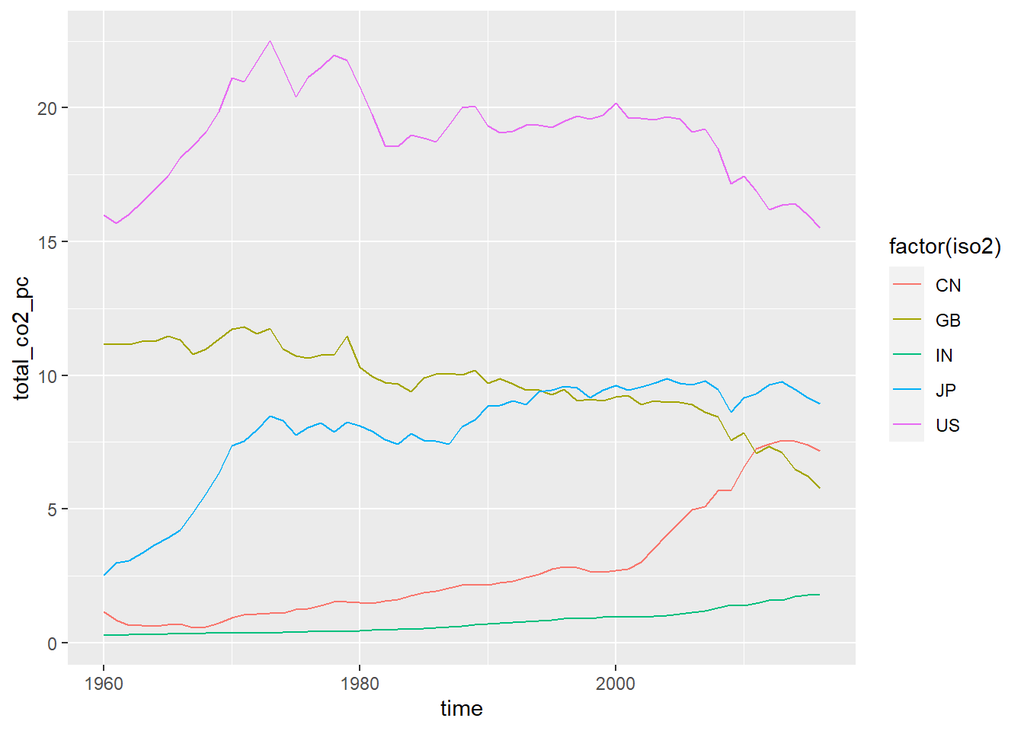

```r
ggplot(data = co2_pc_e, mapping = aes(x = time, y = total_co2_pc, col = factor(iso2))) +
  geom_line()
```

```r
avg_co2_region <- gap %>%
  filter(!is.na(co2_PC) & region != "") %>%
  group_by(region, time) %>%
  summarize(avg_co2_pc = mean(co2_PC))
avg_co2_region
```

```
## # A tibble: 285 × 3
## # Groups:   region [5]
##    region  time avg_co2_pc
##    <chr>  <int>      <dbl>
##  1 Africa  1960      0.291
##  2 Africa  1961      0.300
##  3 Africa  1962      0.299
##  4 Africa  1963      0.310
##  5 Africa  1964      0.349
##  6 Africa  1965      0.385
##  7 Africa  1966      0.422
##  8 Africa  1967      0.607
##  9 Africa  1968      0.781
## 10 Africa  1969      0.824
## # … with 275 more rows
```

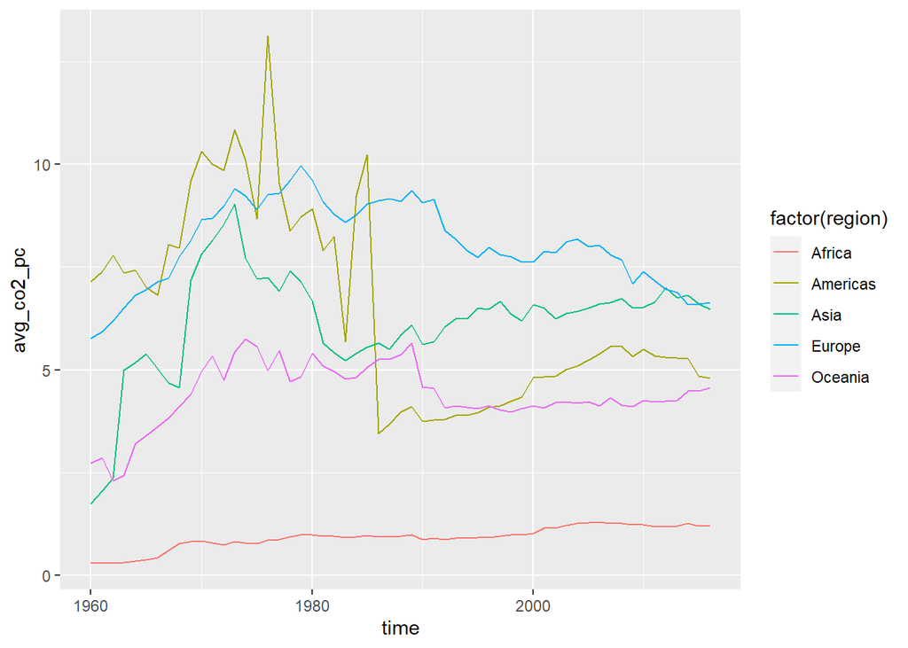

```r
ggplot(data = avg_co2_region, mapping = aes(x = time, y = avg_co2_pc, col = factor(region))) +
  geom_line()
```

```r
bar_data <- gap %>%
  filter(!is.na(co2_PC) & !is.na(region)) %>%
  filter(name != "") %>%
  filter(time == 1960 | time == 2016) %>%
  group_by(region, time) %>%
  mutate(avg_co2_pc = mean(co2_PC))

bar_data
```

```
## # A tibble: 358 × 26
## # Groups:   region, time [10]
##    iso3  name         iso2  region sub.r…¹ inter…²  time total…³ ferti…⁴ lifeE…⁵
##    <chr> <chr>        <chr> <chr>  <chr>   <chr>   <int>   <int>   <dbl>   <dbl>
##  1 ABW   Aruba        AW    Ameri… Latin … "Carib…  1960  5.42e4    4.82    65.7
##  2 ABW   Aruba        AW    Ameri… Latin … "Carib…  2016  1.05e5    1.87    75.9
##  3 AFG   Afghanistan  AF    Asia   Southe… ""       1960  9.00e6    7.45    32.4
##  4 AFG   Afghanistan  AF    Asia   Southe… ""       2016  3.54e7    4.8     63.8
##  5 AGO   Angola       AO    Africa Sub-Sa… "Middl…  1960  5.45e6    6.71    37.5
##  6 AGO   Angola       AO    Africa Sub-Sa… "Middl…  2016  2.88e7    5.69    59.9
##  7 ALB   Albania      AL    Europe Southe… ""       1960  1.61e6    6.49    62.3
##  8 ALB   Albania      AL    Europe Southe… ""       2016  2.88e6    1.66    78.2
##  9 AND   Andorra      AD    Europe Southe… ""       2016  7.73e4   NA       NA
## 10 ARE   United Arab… AE    Asia   Wester… ""       1960  9.24e4    6.93    51.5
## # … with 348 more rows, 16 more variables: childMortality <dbl>,
## #   youthFemaleLiteracy <dbl>, youthMaleLiteracy <dbl>, adultLiteracy <dbl>,
## #   GDP_PC <dbl>, accessElectricity <dbl>, agriculturalLand <dbl>,
## #   agricultureTractors <int>, cerealProduction <int>, fertilizerHa <dbl>,
## #   co2 <dbl>, greenhouseGases <dbl>, co2_PC <dbl>, pm2.5_35 <dbl>,
## #   battleDeaths <int>, avg_co2_pc <dbl>, and abbreviated variable names
## #   ¹sub.region, ²intermediate.region, ³totalPopulation, ⁴fertilityRate, …
```

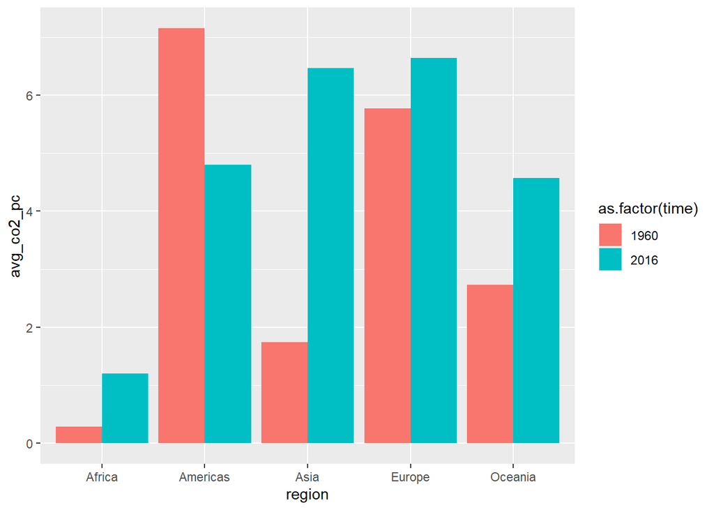

```r
ggplot(data = bar_data, mapping = aes(x = region, y = avg_co2_pc, fill = as.factor(time))) +
  geom_col(position = "dodge")
```

```r
bar_data <- gap %>%
  filter(!is.na(co2_PC) & !is.na(region)) %>%
  filter(name != "") %>%
  filter(time == 2019 | time == 2016) %>%
  group_by(region, time) %>%
  summarise(avg_co2_pc = mean(co2_PC))
bar_data
```

```
## # A tibble: 5 × 3
## # Groups:   region [5]
##   region    time avg_co2_pc
##   <chr>    <int>      <dbl>
## 1 Africa    2016       1.20
## 2 Americas  2016       4.80
## 3 Asia      2016       6.47
## 4 Europe    2016       6.64
## 5 Oceania   2016       4.57
```

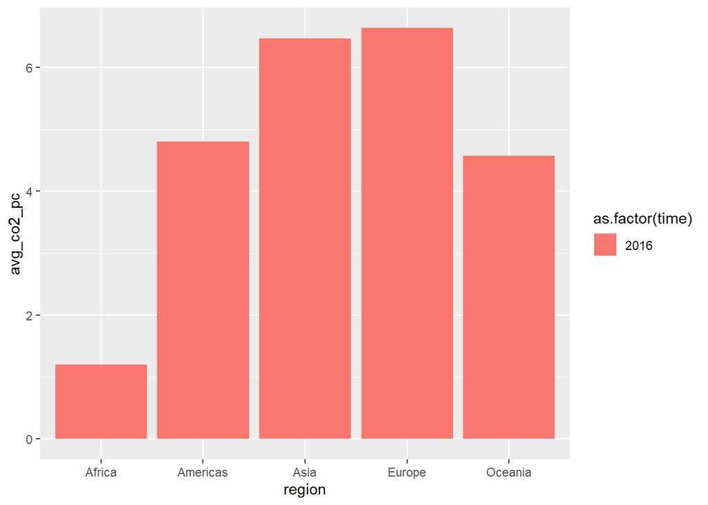

```r
ggplot(data = bar_data, mapping = aes(x = region, y = avg_co2_pc, fill = as.factor(time))) +
  geom_col(position = "dodge")
```

```r
gap %>%
  filter(time == 2019) %>%
  filter(!is.na(co2) | !is.na(co2_PC)) %>%
  nrow()
```

```
## [1] 0
```

## GDP per capita

```r
scatter_data <- gap %>%
  filter(!is.na(GDP_PC) & !is.na(lifeExpectancy) & iso2 != "" & time == 1960) %>%
  group_by(iso2, region)

scatter_data
```

```
## # A tibble: 88 × 25
## # Groups:   iso2, region [88]
##    iso3  name         iso2  region sub.r…¹ inter…²  time total…³ ferti…⁴ lifeE…⁵
##    <chr> <chr>        <chr> <chr>  <chr>   <chr>   <int>   <int>   <dbl>   <dbl>
##  1 ARG   Argentina    AR    Ameri… Latin … "South…  1960  2.05e7    3.11    65.1
##  2 AUS   Australia    AU    Ocean… Austra… ""       1960  1.03e7    3.45    70.8
##  3 AUT   Austria      AT    Europe Wester… ""       1960  7.05e6    2.69    68.6
##  4 BDI   Burundi      BI    Africa Sub-Sa… "Easte…  1960  2.80e6    6.94    41.3
##  5 BEL   Belgium      BE    Europe Wester… ""       1960  9.15e6    2.54    69.7
##  6 BEN   Benin        BJ    Africa Sub-Sa… "Weste…  1960  2.43e6    6.28    37.3
##  7 BFA   Burkina Faso BF    Africa Sub-Sa… "Weste…  1960  4.83e6    6.29    34.4
##  8 BGD   Bangladesh   BD    Asia   Southe… ""       1960  4.80e7    6.72    45.4
##  9 BHS   Bahamas      BS    Ameri… Latin … "Carib…  1960  1.10e5    4.50    64.7
## 10 BLZ   Belize       BZ    Ameri… Latin … "Centr…  1960  9.21e4    6.5     60.0
## # … with 78 more rows, 15 more variables: childMortality <dbl>,
## #   youthFemaleLiteracy <dbl>, youthMaleLiteracy <dbl>, adultLiteracy <dbl>,
## #   GDP_PC <dbl>, accessElectricity <dbl>, agriculturalLand <dbl>,
## #   agricultureTractors <int>, cerealProduction <int>, fertilizerHa <dbl>,
## #   co2 <dbl>, greenhouseGases <dbl>, co2_PC <dbl>, pm2.5_35 <dbl>,
## #   battleDeaths <int>, and abbreviated variable names ¹sub.region,
## #   ²intermediate.region, ³totalPopulation, ⁴fertilityRate, ⁵lifeExpectancy
```

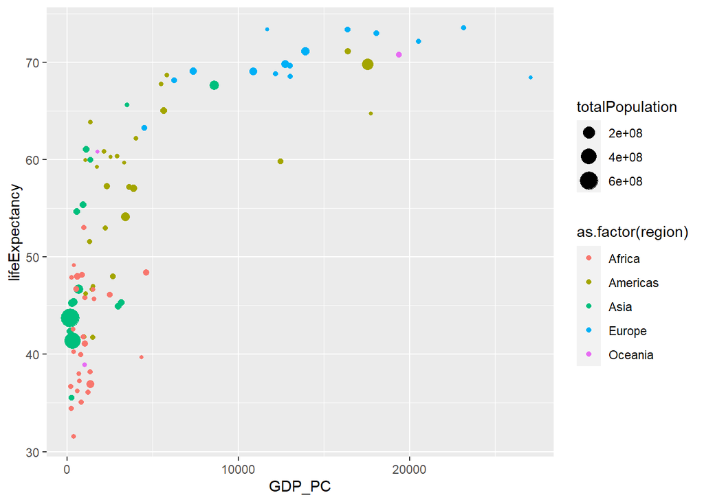

```r
ggplot(data = scatter_data, mapping = aes(x = GDP_PC, y = lifeExpectancy, col = as.factor(region))) +
  geom_point(aes(size = totalPopulation))
```

As the GDP per capita increases, the life expectancy increases. There are more countries in the low GDP_PC proportion than in high GDP_PC proportion. Also, countries in low GDP_PC proportion tend to have more population.Countries in Asia, Africa and Americas are mostly in the low GDP_PC proportion and countries in Europe together with some countries in Americas and Europe are in the high GDP_PC proportion.

```r
scatter_data <- gap %>%
  filter(!is.na(GDP_PC) & !is.na(lifeExpectancy) & iso2 != "" & time == 2019) %>%
  group_by(iso2, region)

scatter_data
```

```
## # A tibble: 177 × 25
## # Groups:   iso2, region [177]
##    iso3  name         iso2  region sub.r…¹ inter…²  time total…³ ferti…⁴ lifeE…⁵
##    <chr> <chr>        <chr> <chr>  <chr>   <chr>   <int>   <int>   <dbl>   <dbl>
##  1 AFG   Afghanistan  AF    Asia   Southe… ""       2019  3.80e7    4.32    64.8
##  2 AGO   Angola       AO    Africa Sub-Sa… "Middl…  2019  3.18e7    5.44    61.1
##  3 ALB   Albania      AL    Europe Southe… ""       2019  2.85e6    1.60    78.6
##  4 ARE   United Arab… AE    Asia   Wester… ""       2019  9.77e6    1.39    78.0
##  5 ARG   Argentina    AR    Ameri… Latin … "South…  2019  4.49e7    2.25    76.7
##  6 ARM   Armenia      AM    Asia   Wester… ""       2019  2.96e6    1.76    75.1
##  7 ATG   Antigua and… AG    Ameri… Latin … "Carib…  2019  9.71e4    1.99    77.0
##  8 AUS   Australia    AU    Ocean… Austra… ""       2019  2.54e7    1.66    82.9
##  9 AUT   Austria      AT    Europe Wester… ""       2019  8.88e6    1.46    81.8
## 10 AZE   Azerbaijan   AZ    Asia   Wester… ""       2019  1.00e7    1.8     73.0
## # … with 167 more rows, 15 more variables: childMortality <dbl>,
## #   youthFemaleLiteracy <dbl>, youthMaleLiteracy <dbl>, adultLiteracy <dbl>,
## #   GDP_PC <dbl>, accessElectricity <dbl>, agriculturalLand <dbl>,
## #   agricultureTractors <int>, cerealProduction <int>, fertilizerHa <dbl>,
## #   co2 <dbl>, greenhouseGases <dbl>, co2_PC <dbl>, pm2.5_35 <dbl>,
## #   battleDeaths <int>, and abbreviated variable names ¹sub.region,
## #   ²intermediate.region, ³totalPopulation, ⁴fertilityRate, ⁵lifeExpectancy
```

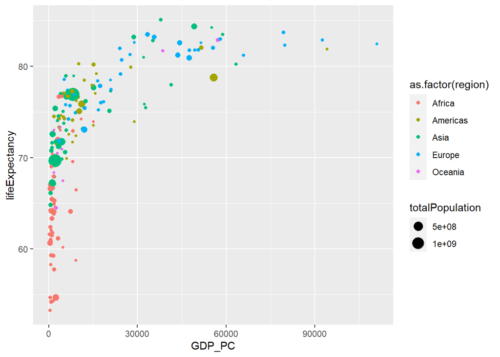

```r
ggplot(data = scatter_data, mapping = aes(x = GDP_PC, y = lifeExpectancy, col = as.factor(region))) +
  geom_point(aes(size = totalPopulation))
```

3. The overall life expectancy and GDP_PC for all countries increases. Almost all African countries are in the low GDP_PC proportion. There are more countries are in the middle proportion. There are less countries in the highest GDP_PC proportion and are all in either Americas or Europe. Almost all Asian countries are in the middle proportion while some have higher life expectancy than the countries with the highest GDP_PC. The overall population size also increased for all countries especially for several Asian countries. Overall, the world have higher GDP_PC and higher life expectancy. Also, most of the countries have similar GDP_PC and life expectancy while countries in Africa still have low GDP_PC and life expectancy.

```r
gap %>%
  filter(!is.na(GDP_PC) & !is.na(lifeExpectancy) & !is.na(region)) %>%
  filter(name != "") %>%
  filter(time == 1960 | time == 2019) %>%
  group_by(region, time) %>%
  summarise(avg_life = mean(lifeExpectancy))
```

```
## # A tibble: 10 × 3
## # Groups:   region [5]
##    region    time avg_life
##    <chr>    <int>    <dbl>
##  1 Africa    1960     41.9
##  2 Africa    2019     64.3
##  3 Americas  1960     57.6
##  4 Americas  2019     75.6
##  5 Asia      1960     50.4
##  6 Asia      2019     74.8
##  7 Europe    1960     70.1
##  8 Europe    2019     79.2
##  9 Oceania   1960     56.9
## 10 Oceania   2019     72.5
```

Yes. Africa countries have the least life expectancy and europe countries have the highest. The countries in the rest of the regions have similar life expectancies.

```r
gap %>%
  filter(!is.na(GDP_PC) & !is.na(lifeExpectancy) & !is.na(region) & !is.na(time)) %>%
  filter(name != "") %>%
  filter(time == 1960 | time == 2019) %>%
  group_by(region, time) %>%
  summarise(avg_life = mean(lifeExpectancy)) %>%
  mutate(growth = avg_life - lag(avg_life)) %>%
  filter(time == 2019) %>%
  arrange(desc(growth))
```

```
## # A tibble: 5 × 4
## # Groups:   region [5]
##   region    time avg_life growth
##   <chr>    <int>    <dbl>  <dbl>
## 1 Asia      2019     74.8  24.5
## 2 Africa    2019     64.3  22.4
## 3 Americas  2019     75.6  18.0
## 4 Oceania   2019     72.5  15.7
## 5 Europe    2019     79.2   9.06
```

Asian countries have the largest growth and Europe countries have the fewest growth. African countries also have high growth, while American and Oceania countries have similar growth.

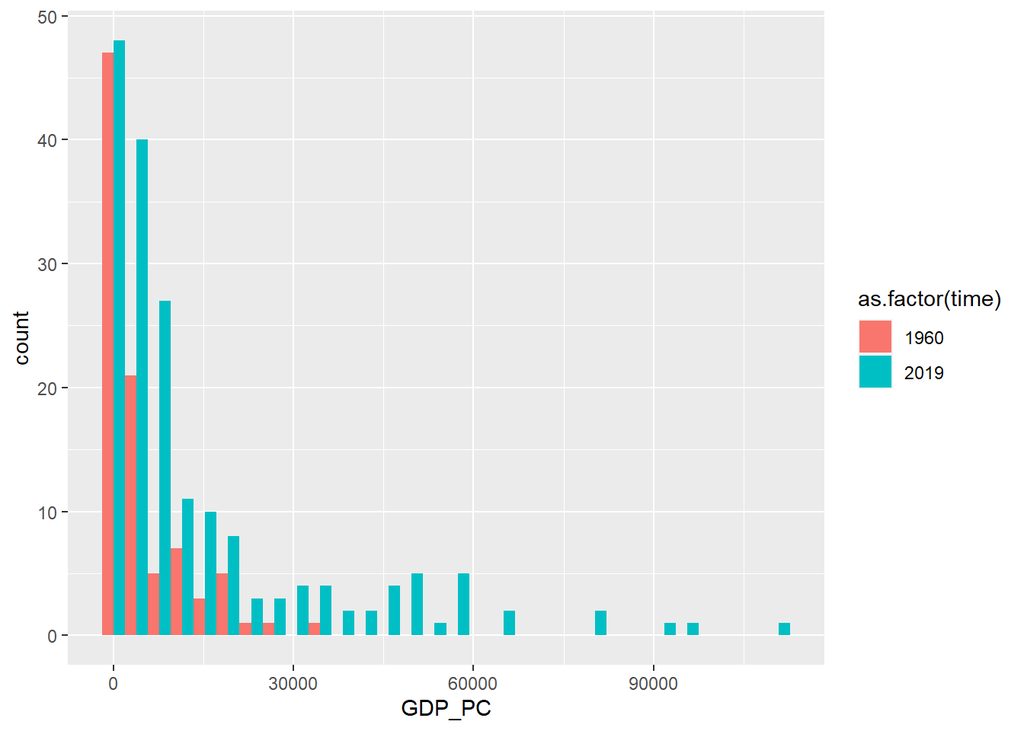

```r
histo_data <- gap %>%
  filter(!is.na(GDP_PC) & !is.na(time)) %>%
  filter(name != "") %>%
  filter(time == 1960 | time == 2019)

ggplot(data = histo_data, mapping = aes(x = GDP_PC, fill = as.factor(time))) +
  geom_histogram(position = 'dodge')
```

```r
gap %>%
  filter(!is.na(lifeExpectancy) & iso2 != "") %>%
  filter(time == 1960 | time == 2019) %>%
  group_by(time) %>%
  summarise(country = iso2, rank = rank(desc(lifeExpectancy))) %>%
  filter(country == "US")
```

```
## # A tibble: 2 × 3
## # Groups:   time [2]
##    time country  rank
##   <int> <chr>   <dbl>
## 1  1960 US         17
## 2  2019 US         46
```

The rank of US in 1960 is 17, and the rank in 2019 is 46.

```r
gap %>%
  filter(!is.na(lifeExpectancy) & name!= "") %>%
  filter(time == 1960 | time == 2019) %>%
  group_by(time) %>%
  summarise(country = name, rank = rank(desc(lifeExpectancy)), num_country = n_distinct(name)) %>%
  filter(country == "United States of America") %>%
  mutate(relative_rank = rank / num_country)
```

```
## # A tibble: 2 × 5
## # Groups:   time [2]
##    time country                   rank num_country relative_rank
##   <int> <chr>                    <dbl>       <int>         <dbl>
## 1  1960 United States of America    17         188        0.0904
## 2  2019 United States of America    46         196        0.235
```

The relative rank in 2019 also decreased for US compared to relative rank in 1960.

## TIME SPENT

**EIGHT HOURS**